# Netflix Recommendation System

## Introduction

I will be implementing a content-based movie/tv show recommender, meaning that content will be recommended based on a movie that a user has watched by finding content similar to it. My goal is to implement a simplistic version of Netflix's "Because You Watched [*Name of Movie/TV Show*]", where based on a particular movie or show that you watched, you are presented with several other movies or shows to watch.

[figure not shown]

The actual Netflix algorithm is much more complicated than the one that I will be creating. Netflix has access to your user data (for example: what time of day you watch, what devices you use, etc.) as well as every other users' data that allows them to identify patterns and use many more features than I have access to (4). More specifically, the "Because You Watched..." algorithm is able to take into account similarities in plots and characters that allows it to "look beyond genre" (2).

```python
# import packages
import numpy as np
import pandas as pd
import matplotlib.pyplot as plt
```

## Who am I?

https://chrome.google.com/webstore/detail/bckfpnenhimfckndcceonmkhheinmkob

```python
my_netflix_df = pd.read_csv('Viewing activity.csv')
my_netflix_df.head()
```

|  | Timestamp | Title | Duration | Duration (s) | Type | Movie ID | Top Node ID | Device Type | Country |
| --- | --- | --- | --- | --- | --- | --- | --- | --- | --- |
| 0 | 2020-04-19T02:49:38.691Z | Don't F**k with Cats: Hunting an Internet Kill... | 01:03:36 | 3816 | Serie | 81031768 | 81031373 | 1222 | US |
| 1 | 2020-04-13T03:47:58.849Z | Don't F**k with Cats: Hunting an Internet Kill... | 57:27 | 3447 | Serie | 81031767 | 81031373 | 1222 | US |
| 2 | 2020-04-13T02:37:17.050Z | Don't F**k with Cats: Hunting an Internet Kill... | 01:05:36 | 3936 | Serie | 81031766 | 81031373 | 1222 | US |
| 3 | 2020-04-12T09:29:57.113Z | Tiger King: Murder, Mayhem and Madness - Limit... | 40:18 | 2418 | Serie | 81276913 | 81115994 | 1222 | US |
| 4 | 2020-04-12T08:50:02.528Z | Tiger King: Murder, Mayhem and Madness - Limit... | 41:24 | 2484 | Serie | 81232944 | 81115994 | 1222 | US |

```python
type(my_netflix_df['Timestamp'][0])
def find_date(timestamp):
    if '2016-01-17' in timestamp:
        return True
    else:
        return False
```

```python
my_netflix_df[my_netflix_df['Timestamp'].apply(find_date)]
```

|  | Timestamp | Title | Duration | Duration (s) | Type | Movie ID | Top Node ID | Device Type | Country |
| --- | --- | --- | --- | --- | --- | --- | --- | --- | --- |
| 1811 | 2016-01-17T23:46:44.944Z | 90210 - Season 3: 'Senior Year, Baby' | 41:00 | 2460 | Serie | 70206945 | 70142388 | 0 | US |
| 1812 | 2016-01-17T23:19:20.094Z | 90210 - Season 2: 'Confessions' | 42:00 | 2520 | Serie | 70206655 | 70142388 | 0 | US |
| 1813 | 2016-01-17T21:49:10.051Z | 90210 - Season 2: 'Javianna' | 41:00 | 2460 | Serie | 70206654 | 70142388 | 0 | US |
| 1814 | 2016-01-17T21:07:24.454Z | 90210 - Season 2: 'Meet the Parent' | 42:00 | 2520 | Serie | 70206653 | 70142388 | 0 | US |
| 1815 | 2016-01-17T20:32:50.896Z | 90210 - Season 2: 'Multiple Choices' | 40:00 | 2400 | Serie | 70206652 | 70142388 | 0 | US |
| 1816 | 2016-01-17T18:52:38.196Z | 90210 - Season 2: 'Another Another Chance' | 42:00 | 2520 | Serie | 70206651 | 70142388 | 0 | US |
| 1817 | 2016-01-17T18:07:52.306Z | 90210 - Season 2: 'Sweaty Palms and Weak Knees' | 41:00 | 2460 | Serie | 70206650 | 70142388 | 0 | US |
| 1818 | 2016-01-17T17:26:32.039Z | 90210 - Season 2: 'Clark Raving Mad' | 42:00 | 2520 | Serie | 70206649 | 70142388 | 0 | US |
| 1819 | 2016-01-17T16:45:55.872Z | 90210 - Season 2: 'What's Past Is Prologue' | 41:00 | 2460 | Serie | 70206648 | 70142388 | 0 | US |
| 1820 | 2016-01-17T08:23:37.942Z | 90210 - Season 2: 'Girl Fight' | 41:00 | 2460 | Serie | 70206647 | 70142388 | 0 | US |
| 1821 | 2016-01-17T07:41:56.492Z | 90210 - Season 2: 'Rats & Heroes' | 41:00 | 2460 | Serie | 70206646 | 70142388 | 0 | US |
| 1822 | 2016-01-17T07:01:01.464Z | 90210 - Season 2: 'Winter Wonderland' | 41:00 | 2460 | Serie | 70206645 | 70142388 | 0 | US |
| 1823 | 2016-01-17T06:19:51.340Z | 90210 - Season 2: 'And Away They Go!' | 42:00 | 2520 | Serie | 70206644 | 70142388 | 0 | US |
| 1824 | 2016-01-17T05:06:17.320Z | 90210 - Season 2: 'To Thine Own Self Be True' | 40:00 | 2400 | Serie | 70206643 | 70142388 | 0 | US |
| 1825 | 2016-01-17T04:24:43.020Z | 90210 - Season 2: 'A Trip to the Moon' | 42:00 | 2520 | Serie | 70206642 | 70142388 | 0 | US |
| 1826 | 2016-01-17T03:43:17.897Z | 90210 - Season 2: 'Women's Intuition' | 41:00 | 2460 | Serie | 70206641 | 70142388 | 0 | US |
| 1827 | 2016-01-17T03:13:12.383Z | 90210 - Season 2: 'Unmasked' | 42:00 | 2520 | Serie | 70206640 | 70142388 | 0 | US |
| 1828 | 2016-01-17T00:04:16.149Z | 90210 - Season 2: 'Wild Alaskan Salmon' | 41:00 | 2460 | Serie | 70206639 | 70142388 | 0 | US |

```python
def find_friends(title):
    if 'Friends -' in title:
        return True
    else:
        return False
```

```python
friends_df = my_netflix_df[my_netflix_df['Title'].apply(find_friends)]
friends_df.head()
def get_name(title):
    return title.split(' -')[0]
series_name = friends_df['Title'].apply(get_name)
```

## Setup

### About the Dataset

The Netflix Movies and TV Shows dataset is from Kaggle and it includes the following columns of data:

| Column Name | Data Type | Description |
| --- | --- | --- |
| show_idUnique | ID | ID for every Movie / TV Show |
| typeIdentifier | String | A Movie or TV Show |
| title | String | Title of the Movie / TV Show |
| director | String | Director of the Movie |
| cast | String | Actors involved in the movie / show |
| country | String | Country where the movie / show was produced |
| date_added | Date | Date it was added on Netflix |
| release_year | Int | Actual Release year of the move / show |
| rating | String | TV Rating of the movie / show |
| duration | String | Total Duration - in minutes or number of seasons |
| listed_in | String | Genre |
| description | String | The summary description |

```python
# read in data
netflix_df = pd.read_csv('netflix_titles.csv')
netflix_df.head()
```

|  | show_id | type | title | director | cast | country | date_added | release_year | rating | duration | listed_in | description |
| --- | --- | --- | --- | --- | --- | --- | --- | --- | --- | --- | --- | --- |
| 0 | 81145628 | Movie | Norm of the North: King Sized Adventure | Richard Finn, Tim Maltby | Alan Marriott, Andrew Toth, Brian Dobson, Cole... | United States, India, South Korea, China | September 9, 2019 | 2019 | TV-PG | 90 min | Children & Family Movies, Comedies | Before planning an awesome wedding for his gra... |
| 1 | 80117401 | Movie | Jandino: Whatever it Takes | NaN | Jandino Asporaat | United Kingdom | September 9, 2016 | 2016 | TV-MA | 94 min | Stand-Up Comedy | Jandino Asporaat riffs on the challenges of ra... |
| 2 | 70234439 | TV Show | Transformers Prime | NaN | Peter Cullen, Sumalee Montano, Frank Welker, J... | United States | September 8, 2018 | 2013 | TV-Y7-FV | 1 Season | Kids' TV | With the help of three human allies, the Autob... |
| 3 | 80058654 | TV Show | Transformers: Robots in Disguise | NaN | Will Friedle, Darren Criss, Constance Zimmer, ... | United States | September 8, 2018 | 2016 | TV-Y7 | 1 Season | Kids' TV | When a prison ship crash unleashes hundreds of... |
| 4 | 80125979 | Movie | #realityhigh | Fernando Lebrija | Nesta Cooper, Kate Walsh, John Michael Higgins... | United States | September 8, 2017 | 2017 | TV-14 | 99 min | Comedies | When nerdy high schooler Dani finally attracts... |

```python
netflix_df.shape
```

```
(6234, 12)
```

**Check for Null Values**

```python
# check for null values
netflix_df.isna().sum()
```

```
show_id            0
type               0
title              0
director        1969
cast             570
country          476
date_added        11
release_year       0
rating            10
duration           0
listed_in          0
description        0
dtype: int64
```

```python
# fill in 'director', 'cast', and 'country' nan values with empty strings
netflix_df[['director', 'cast', 'country']] = netflix_df[['director', 'cast', 'country']].fillna('')
```

```python
# get top 3
def top_3(this_list):
    if len(this_list) > 3:
        return this_list[:3]
    else:
        return this_list

# convert to lowercase and strip whitespace
def clean_list(this_list):
    return [str.lower(i.replace(" ", "")) for i in this_list]

# convert comma-separated strings in dataframe to lists
features = ['director', 'cast', 'country', 'listed_in']
for feature in features:
    netflix_df[feature] = netflix_df[feature].str.split(', ')
    netflix_df[feature] = netflix_df[feature].apply(top_3)
    netflix_df[feature] = netflix_df[feature].apply(clean_list)

netflix_df
```

|  | show_id | type | title | director | cast | country | date_added | release_year | rating | duration | listed_in | description |
| --- | --- | --- | --- | --- | --- | --- | --- | --- | --- | --- | --- | --- |
| 0 | 81145628 | Movie | Norm of the North: King Sized Adventure | [richardfinn, timmaltby] | [alanmarriott, andrewtoth, briandobson] | [unitedstates, india, southkorea] | September 9, 2019 | 2019 | TV-PG | 90 min | [children&familymovies, comedies] | Before planning an awesome wedding for his gra... |
| 1 | 80117401 | Movie | Jandino: Whatever it Takes | [] | [jandinoasporaat] | [unitedkingdom] | September 9, 2016 | 2016 | TV-MA | 94 min | [stand-upcomedy] | Jandino Asporaat riffs on the challenges of ra... |
| 2 | 70234439 | TV Show | Transformers Prime | [] | [petercullen, sumaleemontano, frankwelker] | [unitedstates] | September 8, 2018 | 2013 | TV-Y7-FV | 1 Season | [kids'tv] | With the help of three human allies, the Autob... |
| 3 | 80058654 | TV Show | Transformers: Robots in Disguise | [] | [willfriedle, darrencriss, constancezimmer] | [unitedstates] | September 8, 2018 | 2016 | TV-Y7 | 1 Season | [kids'tv] | When a prison ship crash unleashes hundreds of... |
| 4 | 80125979 | Movie | #realityhigh | [fernandolebrija] | [nestacooper, katewalsh, johnmichaelhiggins] | [unitedstates] | September 8, 2017 | 2017 | TV-14 | 99 min | [comedies] | When nerdy high schooler Dani finally attracts... |
| ... | ... | ... | ... | ... | ... | ... | ... | ... | ... | ... | ... | ... |
| 6229 | 80000063 | TV Show | Red vs. Blue | [] | [burnieburns, jasonsaldaña, gustavosorola] | [unitedstates] | NaN | 2015 | NR | 13 Seasons | [tvaction&adventure, tvcomedies, tvsci-fi&fant... | This parody of first-person shooter games, mil... |
| 6230 | 70286564 | TV Show | Maron | [] | [marcmaron, juddhirsch, joshbrener] | [unitedstates] | NaN | 2016 | TV-MA | 4 Seasons | [tvcomedies] | Marc Maron stars as Marc Maron, who interviews... |
| 6231 | 80116008 | Movie | Little Baby Bum: Nursery Rhyme Friends | [] | [] | [] | NaN | 2016 | NaN | 60 min | [movies] | Nursery rhymes and original music for children... |
| 6232 | 70281022 | TV Show | A Young Doctor's Notebook and Other Stories | [] | [danielradcliffe, jonhamm, adamgodley] | [unitedkingdom] | NaN | 2013 | TV-MA | 2 Seasons | [britishtvshows, tvcomedies, tvdramas] | Set during the Russian Revolution, this comic ... |
| 6233 | 70153404 | TV Show | Friends | [] | [jenniferaniston, courteneycox, lisakudrow] | [unitedstates] | NaN | 2003 | TV-14 | 10 Seasons | [classic&culttv, tvcomedies] | This hit sitcom follows the merry misadventure... |

6234 rows × 12 columns

```python
def clean_element(this_element):
    return str.lower(this_element.replace(" ", ""))

netflix_df['type'] = netflix_df['type'].apply(clean_element)
```

```python
#indices = pd.Series(netflix_df.index, index=netflix_df['title']).drop_duplicates()
#indices
```

```python
def create_soup(df):
    return (df['type'] + ' '
            + ' '.join(df['director']) + ' '
            + ' '.join(df['cast']) + ' '
            + ' '.join(df['country']) + ' '
            + ' '.join(df['listed_in']))
```

```python
netflix_df['soup'] = netflix_df.apply(create_soup, axis=1)
# Ex: 6007 is the index of the netflix_df that represents "Parks and Recreation"
netflix_df['soup'][6007]
```

```
'tvshow  amypoehler rashidajones azizansari unitedstates tvcomedies'
```

```python
netflix_df[netflix_df['title'] == 'Friends']
#netflix_df['soup'][5879]
```

|  | show_id | type | title | director | cast | country | date_added | release_year | rating | duration | listed_in | description | soup |
| --- | --- | --- | --- | --- | --- | --- | --- | --- | --- | --- | --- | --- | --- |
| 6233 | 70153404 | tvshow | Friends | [] | [jenniferaniston, courteneycox, lisakudrow] | [unitedstates] | NaN | 2003 | TV-14 | 10 Seasons | [classic&culttv, tvcomedies] | This hit sitcom follows the merry misadventure... | tvshow jenniferaniston courteneycox lisakudro... |

## Exploratory Data Visualization

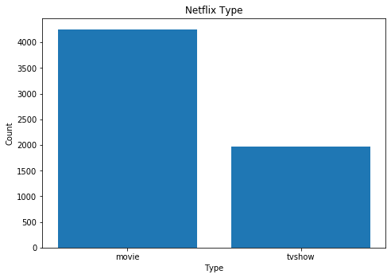

```python
netflix_type = netflix_df.groupby(['type']).count()

fig = plt.figure()
ax = fig.add_axes([0,0,1,1])
ax.bar(netflix_type.index, netflix_type['rating'])

plt.xlabel('Type')
plt.ylabel('Count')
plt.title('Netflix Type')

plt.show()
```

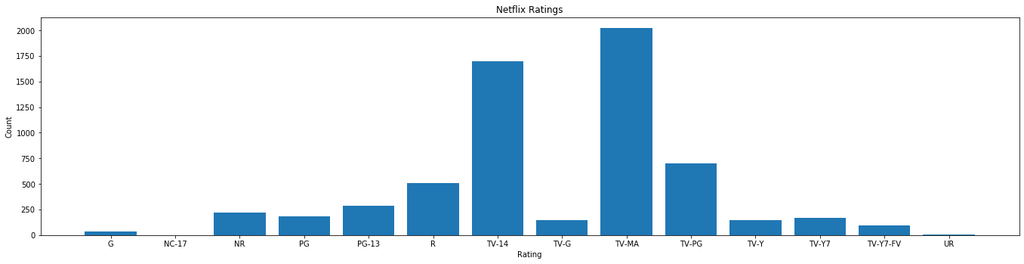

```python
netflix_ratings = netflix_df.groupby(['rating']).count()

fig = plt.figure()
ax = fig.add_axes([0,0,3,1])
ax.bar(netflix_ratings.index, netflix_ratings['type'])

plt.xlabel('Rating')
plt.ylabel('Count')
plt.title('Netflix Ratings')

plt.show()
```

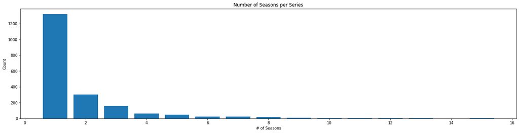

```python
def find_num(string):
    x = string.split(" ")
    return int(x[0])

netflix_duration = netflix_df
netflix_duration['duration'] = netflix_duration['duration'].apply(find_num)

netflix_duration = netflix_df[netflix_df['type'] == 'tvshow']
netflix_duration = netflix_duration.groupby(['duration']).count()

fig = plt.figure()
ax = fig.add_axes([0,0,3,1])
ax.bar(netflix_duration.index, netflix_duration['type'])

plt.xlabel('# of Seasons')
plt.ylabel('Count')
plt.title('Number of Seasons per Series')


plt.show()
#netflix_duration.index
```

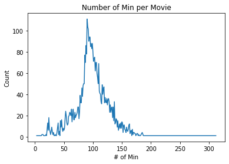

```python
def find_min(string):
    x = string.split(" ")
    return int(x[0])

netflix_duration_movie = netflix_df
#netflix_duration_movie['duration'] = netflix_duration_movie['duration'].apply(find_min)

netflix_duration_movie = netflix_df[netflix_df['type'] == 'movie']
netflix_duration_movie = netflix_duration_movie.groupby(['duration']).count()

fig = plt.figure()
plt.plot(netflix_duration_movie.index, netflix_duration_movie['type'])
#ax.line(netflix_duration_movie.index, netflix_duration_movie['type'])

plt.xlabel('# of Min')
plt.ylabel('Count')
plt.title('Number of Min per Movie')


plt.show()
```

## Creating the Classifier

```python
# Import CountVectorizer and create the count matrix
from sklearn.feature_extraction.text import CountVectorizer

count = CountVectorizer(stop_words='english')
count_matrix = count.fit_transform(netflix_df['soup'])
```

```python
def clean_element(this_element):
    return str.lower(this_element.replace(" ", ""))

netflix_df['description'] = netflix_df['description'].str.lower()
netflix_df['description'] = netflix_df['description'].str.replace(',', '')
netflix_df['description'] = netflix_df['description'].str.replace('.', '')
netflix_df['description'] = netflix_df['description'].str.replace('\W+', ' ')
netflix_df['description'] = netflix_df['description'].str.replace('\d+', '')
# test
count_test = CountVectorizer(stop_words='english')
count_matrix_test = count_test.fit_transform(netflix_df['description'])
doc_term_matrix2 = count_matrix_test.todense()
df2 = pd.DataFrame(doc_term_matrix2,
                  columns=count_test.get_feature_names())
#df2
```

```python
doc_term_matrix = count_matrix.todense()
df = pd.DataFrame(doc_term_matrix,
                  columns=count.get_feature_names())
doc_term_matrix
df.head()
```

|  | 4minute | 50cent | aadarshbalakrishna | aadhi | aadishkeluskar | aadukalamnaren | aahanakumra | aakarshansingh | aakashpandey | aaminasheikh | ... | ümitbülentdinçer | þorsteinnbachmann | łoza | łukasz | şafakpekdemir | şafaksezer | şebnembozoklu | şenaygürler | şenolsönmez | şükrüözyıldız |
| --- | --- | --- | --- | --- | --- | --- | --- | --- | --- | --- | --- | --- | --- | --- | --- | --- | --- | --- | --- | --- | --- |
| 0 | 0 | 0 | 0 | 0 | 0 | 0 | 0 | 0 | 0 | 0 | ... | 0 | 0 | 0 | 0 | 0 | 0 | 0 | 0 | 0 | 0 |
| 1 | 0 | 0 | 0 | 0 | 0 | 0 | 0 | 0 | 0 | 0 | ... | 0 | 0 | 0 | 0 | 0 | 0 | 0 | 0 | 0 | 0 |
| 2 | 0 | 0 | 0 | 0 | 0 | 0 | 0 | 0 | 0 | 0 | ... | 0 | 0 | 0 | 0 | 0 | 0 | 0 | 0 | 0 | 0 |
| 3 | 0 | 0 | 0 | 0 | 0 | 0 | 0 | 0 | 0 | 0 | ... | 0 | 0 | 0 | 0 | 0 | 0 | 0 | 0 | 0 | 0 |
| 4 | 0 | 0 | 0 | 0 | 0 | 0 | 0 | 0 | 0 | 0 | ... | 0 | 0 | 0 | 0 | 0 | 0 | 0 | 0 | 0 | 0 |

5 rows × 14232 columns

```python
# Implement Cosine Similarity

# Helper Function: Dot Product
def dot_product(vector1, vector2):
    sums = 0
    for i in vector1:
        product = vector1[i] * vector2[i]
        sums += product
    return sums

# Helper Function: Magnitude of a Vector
def vector_mag(vector):
    sums = 0
    for i in vector:
        sums += i ** 2
    # return the square root of sums
    return sums ** (1/2)

# Helper function: Calculate the cosine similarity between two vectors
def cosine_sim_vect(vector1, vector2):
    # check that the sizes of the vectors are the same
    if (len(vector1) != len(vector2)):
        new_length = min(len(vector1), len(vector2))
        vector1 = vector1[:new_length]
        vector2 = vector2[:new_length]
    # compute dot product between the two vectors
    dotprod = dot_product(vector1, vector2)
    # find the magnitude of each vector
    mag1 = vector_mag(vector1)
    mag2 = vector_mag(vector2)

    return dotprod / (mag1 * mag2)

# Calculate cosine similairity between all vectors in the dataframe
def my_cosine_similarity(matrix1, matrix2):
    cos_sim_matrix = pd.DataFrame(columns=matrix1.columns)
    for row in matrix1.index:
        for row2 in matrix2.index:
            sim_vector = []
            sim_vector.append(cosine_sim_vect(matrix1.iloc[row], matrix2.iloc[row2]))
        cos_sim_matrix.append(sim_vector)
    return cos_sim_matrix
```

```python
df_test = pd.DataFrame(columns=df.columns)
#df_ = df_.fillna(0)
df_test
```

|  | 4minute | 50cent | aadarshbalakrishna | aadhi | aadishkeluskar | aadukalamnaren | aahanakumra | aakarshansingh | aakashpandey | aaminasheikh | ... | ümitbülentdinçer | þorsteinnbachmann | łoza | łukasz | şafakpekdemir | şafaksezer | şebnembozoklu | şenaygürler | şenolsönmez | şükrüözyıldız |
| --- | --- | --- | --- | --- | --- | --- | --- | --- | --- | --- | --- | --- | --- | --- | --- | --- | --- | --- | --- | --- | --- |

0 rows × 14232 columns

```python
cosine_sim_vect(df.iloc[6217], df.iloc[5702])
#netflix_df[netflix_df['title'] == 'Gilmore Girls']
#6217, 5702
```

```
0.0
```

```python
# Compute the Cosine Similarity matrix based on the count_matrix
from sklearn.metrics.pairwise import cosine_similarity

cosine_sim = cosine_similarity(count_matrix, count_matrix)
```

```python
cosine_sim.shape
#cosine_sim
```

```
(6234, 6234)
```

```python
# Reset index of your main DataFrame and construct reverse mapping as before
netflix_df = netflix_df.reset_index()
indices = pd.Series(netflix_df.index, index=netflix_df['title'])

indices
```

```
title
Norm of the North: King Sized Adventure           0
Jandino: Whatever it Takes                        1
Transformers Prime                                2
Transformers: Robots in Disguise                  3
#realityhigh                                      4
                                               ...
Red vs. Blue                                   6229
Maron                                          6230
Little Baby Bum: Nursery Rhyme Friends         6231
A Young Doctor's Notebook and Other Stories    6232
Friends                                        6233
Length: 6234, dtype: int64
```

```python
# Function that takes in movie title as input and outputs most similar movies
# Reference: Rounak Banik,'Recommender Systems in Python: Beginner Tutorial'
def get_recommendations(title, cosine_sim=cosine_sim):
    # Get the index of the movie that matches the title
    idx = indices[title]

    # Get the pairwsie similarity scores of all movies with that movie
    sim_scores = list(enumerate(cosine_sim[idx]))

    # Sort the movies based on the similarity scores
    sim_scores = sorted(sim_scores, key=lambda x: x[1], reverse=True)

    # Get the scores of the 10 most similar movies
    sim_scores = sim_scores[1:11]

    # Get the movie indices
    movie_indices = [i[0] for i in sim_scores]

    # Return the top 10 most similar movies
    return netflix_df['title'].iloc[movie_indices]
```

```python
test = get_recommendations('New Girl', cosine_sim).reset_index().drop(['index'], axis=1)
test.index += 1
test
```

|  | title |
| --- | --- |
| 1 | Hot Date |
| 2 | Crazy Ex-Girlfriend |
| 3 | Melodies of Life - Born This Way |
| 4 | Conan Without Borders |
| 5 | Dancing Angels |
| 6 | No Tomorrow |
| 7 | Accidentally in Love |
| 8 | Charmed |
| 9 | Gilmore Girls |
| 10 | She's Gotta Have It |

```python
title=input()
```

```
Gilmore Girls
```

```python
try:
    print(get_recommendations(title, cosine_sim))
except:
    print("Sorry, this title is not in the current dataset!")
```

```
1116    Gilmore Girls: A Year in the Life
54                            No Tomorrow
5700                              Charmed
5797                  She's Gotta Have It
5844                          On My Block
6131                      Jane The Virgin
5825                                 Love
867                              Hot Date
1669                           Dramaworld
135                               BONDING
Name: title, dtype: object
```

## References:

1. Dataset: [Kaggle: Netflix Movies and TV Shows](https://www.kaggle.com/shivamb/netflix-shows)
2. Article: [Netflix Finally Explains How its 'Because You Watched' Recommendation Tool Works](https://qz.com/1059434/netflix-finally-explains-how-its-because-you-watched-recommendation-tool-works/)
3. [Recommendation Systems](https://medium.com/@pytholabs/recommendation-systems-from-scratch-in-python-pytholabs-6946491e76c2)
4. [How Netflix’s Recommendations System Works](https://help.netflix.com/en/node/100639)
5. [Recommender Systems in Python: Beginner Tutorial](https://www.datacamp.com/community/tutorials/recommender-systems-python)
6. [Netflix Prize](https://www.thrillist.com/entertainment/nation/the-netflix-prize)